# Lab 3 Markdown

Nicole Bohra

1/28/2019

## Section 1:

```r
setwd("/Users/nicolebohra/INFO371/Labs")
wvs<- read.delim("wvs.csv.bz2", header = TRUE)
summary(wvs)
```

```
##      choice       country       sex            age           religion
##  Min.   : 1.000   CH:2039   female:2147   Min.   :18.00   Min.   :1.000
##  1st Qu.: 6.000   US:2154   male  :2046   1st Qu.:33.00   1st Qu.:4.000
##  Median : 8.000                           Median :46.00   Median :7.000
##  Mean   : 7.469                           Mean   :46.37   Mean   :5.411
##  3rd Qu.: 9.000                           3rd Qu.:59.00   3rd Qu.:7.000
##  Max.   :10.000                           Max.   :93.00   Max.   :7.000
##  education     class
##  <HS: 852   lower :1757
##  C  :1155   middle:1624
##  HS :1739   upper : 812
##  SC : 447
##
##
```

#### Plot:

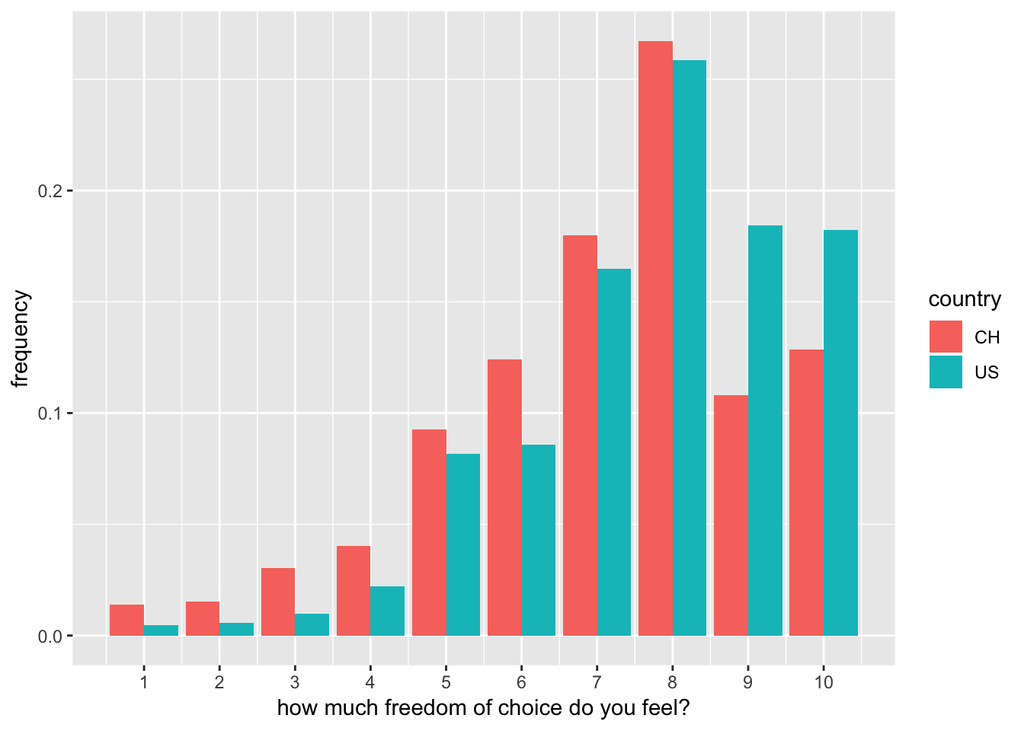

```r
ggplot(wvs) +
  geom_bar(aes(choice, y = ..prop.., fill = country), position = "dodge") +
  scale_x_continuous(breaks = 1:10) +
  labs(y = "frequency", x = "how much freedom of choice do you feel?")
```

#### 1: Linear model between choice and country

```r
model <- lm(choice~country, data = wvs)
summary(model)
```

```
##
## Call:
## lm(formula = choice ~ country, data = wvs)
##
## Residuals:
##     Min      1Q  Median      3Q     Max
## -6.7637 -1.1584  0.2363  1.2363  2.8416
##
## Coefficients:
##             Estimate Std. Error t value Pr(>|t|)
## (Intercept)  7.15841    0.04189  170.88   <2e-16 ***
## countryUS    0.60528    0.05845   10.36   <2e-16 ***
## ---
## Signif. codes:  0 '***' 0.001 '**' 0.01 '*' 0.05 '.' 0.1 ' ' 1
##
## Residual standard error: 1.892 on 4191 degrees of freedom
## Multiple R-squared:  0.02495,    Adjusted R-squared:  0.02472
## F-statistic: 107.2 on 1 and 4191 DF,  p-value: < 2.2e-16
```

#### 2:

> American respondents feel 0.6 units more “freedom” than Chinese respondents. In total, Americans are at a Freedom Index of 7.7 in responding versus Chinese respondents having about an index of 7.1.

#### 3:

> The r2 value tells us that 2.5% of the variance in the data can be explained by the model.

## Section 2:

#### 1: Linear model between choice, country and sex

```r
model_sex <- lm(choice~country + sex, data = wvs)
summary(model_sex)
```

```
##
## Call:
## lm(formula = choice ~ country + sex, data = wvs)
##
## Residuals:
##     Min      1Q  Median      3Q     Max
## -6.7915 -1.1293  0.2085  1.2660  2.8707
##
## Coefficients:
##             Estimate Std. Error t value Pr(>|t|)
## (Intercept)  7.18674    0.05084 141.358   <2e-16 ***
## countryUS    0.60473    0.05845  10.346   <2e-16 ***
## sexmale     -0.05748    0.05845  -0.983    0.325
## ---
## Signif. codes:  0 '***' 0.001 '**' 0.01 '*' 0.05 '.' 0.1 ' ' 1
##
## Residual standard error: 1.892 on 4190 degrees of freedom
## Multiple R-squared:  0.02518,    Adjusted R-squared:  0.02471
## F-statistic: 54.11 on 2 and 4190 DF,  p-value: < 2.2e-16
```

#### 2:

> 1. The level of choice freedom for American men would be about 7.73.
> 2. The level of choice freedom for American women would be about 7.79.
> 3. The level of choice freedom for Chinese men would be about 7.13.
> 4. The level of choice freedom for Chinese women would be about 7.19.

## Section 3: Sex x Country

#### 1: Linear model with interaction effect

```r
model_3 <- lm(choice~sex*country, data = wvs)
summary(model_3)
```

```
##
## Call:
## lm(formula = choice ~ sex * country, data = wvs)
##
## Residuals:
##     Min      1Q  Median      3Q     Max
## -6.9111 -1.0580  0.0889  1.3939  2.9420
##
## Coefficients:
##                   Estimate Std. Error t value Pr(>|t|)
## (Intercept)        7.05803    0.05870 120.236  < 2e-16 ***
## sexmale            0.20366    0.08361   2.436   0.0149 *
## countryUS          0.85302    0.08153  10.463  < 2e-16 ***
## sexmale:countryUS -0.50857    0.11668  -4.359 1.34e-05 ***
## ---
## Signif. codes:  0 '***' 0.001 '**' 0.01 '*' 0.05 '.' 0.1 ' ' 1
##
## Residual standard error: 1.888 on 4189 degrees of freedom
## Multiple R-squared:  0.02958,    Adjusted R-squared:  0.02888
## F-statistic: 42.56 on 3 and 4189 DF,  p-value: < 2.2e-16
```

#### 3:

> Based on the dataset, it seems that women are more free or have a higher perceived freedom. However, it depends on what country we are looking at.